# TOD_Washington_DC

Xiong_Zheng

9/23/2021

## Motivation

##### Washington DC is the national leader in TOD. It offers an incredible opportunity to learn from the multiple generations of TOD projects that have been built across the region. This research is carried out for observing whether households value transit-rich neighborhoods in such a TOD-famous city.

## Setting

##### Load libraries

```r
library(tidyverse)
library(tidycensus)
library(sf)
library(kableExtra)
```

##### Define functions

```r
options(scipen=999)
options(tigris_class = "sf")

mapTheme <- function(base_size = 12) {
  theme(
    text = element_text( color = "black"),
    plot.title = element_text(size = 16,colour = "black"),
    plot.subtitle=element_text(face="italic"),
    plot.caption=element_text(hjust=0),
    axis.ticks = element_blank(),
    panel.background = element_blank(),axis.title = element_blank(),
    axis.text = element_blank(),
    axis.title.x = element_blank(),
    axis.title.y = element_blank(),
    panel.grid.minor = element_blank(),
    panel.border = element_rect(colour = "black", fill=NA, size=2),
    strip.text.x = element_text(size = 14))
}

plotTheme <- function(base_size = 12) {
  theme(
    text = element_text( color = "black"),
    plot.title = element_text(size = 16,colour = "black"),
    plot.subtitle = element_text(face="italic"),
    plot.caption = element_text(hjust=0),
    axis.ticks = element_blank(),
    panel.background = element_blank(),
    panel.grid.major = element_line("grey80", size = 0.1),
    panel.grid.minor = element_blank(),
    panel.border = element_rect(colour = "black", fill=NA, size=2),
    strip.background = element_rect(fill = "grey80", color = "white"),
    strip.text = element_text(size=12),
    axis.title = element_text(size=12),
    axis.text = element_text(size=10),
    plot.background = element_blank(),
    legend.background = element_blank(),
    legend.title = element_text(colour = "black", face = "italic"),
    legend.text = element_text(colour = "black", face = "italic"),
    strip.text.x = element_text(size = 14)
  )
}

qBr <- function(df, variable, rnd) {
  if (missing(rnd)) {
    as.character(quantile(round(df[[variable]],0),
                          c(.01,.2,.4,.6,.8), na.rm=T))
  } else if (rnd == FALSE | rnd == F) {
    as.character(formatC(quantile(df[[variable]]), digits = 3),
                 c(.01,.2,.4,.6,.8), na.rm=T)
  }
}

q5 <- function(variable) {as.factor(ntile(variable, 5))}

multipleRingBuffer <- function(inputPolygon, maxDistance, interval)
{
  distances <- seq(0, maxDistance, interval)
  distancesCounter <- 2
  numberOfRings <- floor(maxDistance / interval)
  numberOfRingsCounter <- 1
  allRings <- data.frame()

  while (numberOfRingsCounter <= numberOfRings)
  {
    if(distances[distancesCounter] < 0 & distancesCounter == 2)
    {
      buffer1 <- st_buffer(inputPolygon, distances[distancesCounter])
      buffer1_ <- st_difference(inputPolygon, buffer1)
      thisRing <- st_cast(buffer1_, "POLYGON")
      #take the last column which is 'geometry'
      thisRing <- as.data.frame(thisRing[,ncol(thisRing)])
      thisRing$distance <- distances[distancesCounter]
    }

    else if(distances[distancesCounter] < 0 & distancesCounter > 2)
    {
      buffer1 <- st_buffer(inputPolygon, distances[distancesCounter])
      buffer2 <- st_buffer(inputPolygon, distances[distancesCounter-1])
      thisRing <- st_difference(buffer2,buffer1)
      thisRing <- st_cast(thisRing, "POLYGON")
      thisRing <- as.data.frame(thisRing$geometry)
      thisRing$distance <- distances[distancesCounter]
    }

    else
    {
      buffer1 <- st_buffer(inputPolygon, distances[distancesCounter])
      buffer1_ <- st_buffer(inputPolygon, distances[distancesCounter-1])
      thisRing <- st_difference(buffer1,buffer1_)
      thisRing <- st_cast(thisRing, "POLYGON")
      #geometry column as a data frame
      thisRing <- as.data.frame(thisRing[,ncol(thisRing)])
      thisRing$distance <- distances[distancesCounter]
    }

    allRings <- rbind(allRings, thisRing)
    distancesCounter <- distancesCounter + 1
    numberOfRingsCounter <- numberOfRingsCounter + 1
  }
  allRings <- st_as_sf(allRings)
}

palette5 <- c("#2166ac","#67a9cf","#d1e5f0","#fddbc7","#ef8a62")
```

##### API

```r
census_api_key("b33ec1cb4da108659efd12b3c15412988646cbd8", overwrite = TRUE,instal = TRUE)
```

## Data Wrangling

##### Read 2009 & 2019 Census Data

```r
acs_variable_list.2019 <- load_variables(2019,"acs5",cache = TRUE)
acs_variable_list.2009 <- load_variables(2009,"acs5",cache = TRUE)

rawdata19 <-
  get_acs(geography = "tract", variables = c("B25026_001E","B02001_002E","B15001_050E",
                                             "B15001_009E","B19013_001E","B25058_001E",
                                             "B06012_002E"),
          year=2019, state=11, county=001, geometry=T, output="wide") %>%
  st_transform('EPSG:26918') %>%
  rename(TotalPop = B25026_001E,
         Whites = B02001_002E,
         FemaleBachelors = B15001_050E,
         MaleBachelors = B15001_009E,
         MedHHInc = B19013_001E,
         MedRent = B25058_001E,
         TotalPoverty = B06012_002E) %>%
  dplyr::select(-NAME,-starts_with("B")) %>%
  mutate(pctWhite = ifelse(TotalPop > 0, Whites / TotalPop,0),
         pctBachelors = ifelse(TotalPop > 0, ((FemaleBachelors + MaleBachelors) / TotalPop),0),
         pctPoverty = ifelse(TotalPop > 0, TotalPoverty / TotalPop, 0),
         year = "2019") %>%
  dplyr::select(-Whites, -FemaleBachelors, -MaleBachelors, -TotalPoverty)


rawdata09 <-
  get_acs(geography = "tract", variables = c("B25026_001E","B02001_002E","B15001_050E",
                                             "B15001_009E","B19013_001E","B25058_001E",
                                             "B06012_002E"),
          year=2009, state=11, county=001, geometry=T, output="wide") %>%
  st_transform('EPSG:26918') %>%
  rename(TotalPop = B25026_001E,
         Whites = B02001_002E,
         FemaleBachelors = B15001_050E,
         MaleBachelors = B15001_009E,
         MedHHInc = B19013_001E,
         MedRent = B25058_001E,
         TotalPoverty = B06012_002E) %>%
  dplyr::select(-NAME,-starts_with("B")) %>%
  mutate(pctWhite = ifelse(TotalPop > 0, Whites / TotalPop,0),
         pctBachelors = ifelse(TotalPop > 0, ((FemaleBachelors + MaleBachelors) / TotalPop),0),
         pctPoverty = ifelse(TotalPop > 0, TotalPoverty / TotalPop, 0),
         year = "2009") %>%
  dplyr::select(-Whites, -FemaleBachelors, -MaleBachelors, -TotalPoverty)
```

##### Join 2009 & 2019 Census Data

```r
crowdata <- rbind(rawdata09,rawdata19)
unionbdry <- st_union(rawdata19) %>%
  st_sf()
```

##### Read DC Transportation Data

```r
WMATAStops <-
  (st_read("https://opendata.arcgis.com/datasets/54018b7f06b943f2af278bbe415df1de_52.geojson") %>%
  select(NAME, LINE)) %>%
  st_transform(st_crs(rawdata19))
```

##### Define TOD Area

```r
WMATABuffers <-
  rbind(st_buffer(WMATAStops, 804.672)%>%
          mutate(Legend = "Buffer")%>%
          dplyr::select(Legend),
        st_union(st_buffer(WMATAStops, 804.672)) %>%
          st_sf() %>%
          mutate(Legend = "Unioned Buffer"))
```

##### Join TOD Area

```r
justbuffer <- st_union(st_buffer(WMATAStops, 804.672)) %>%
  st_sf()
```

##### Identify each tract is in TOD area or not

```r
crowdata_todornot <-
  rbind(
    st_centroid(crowdata)[justbuffer,] %>%
      st_drop_geometry() %>%
      left_join(crowdata) %>%
      st_sf() %>%
      mutate(TOD = "TOD"),
    st_centroid(crowdata)[justbuffer, op = st_disjoint] %>%
      st_drop_geometry() %>%
      left_join(crowdata) %>%
      st_sf() %>%
      mutate(TOD = "Non-TOD"))
```

##### Wrangle the Indicators of data

```r
crowdata_todornot <-
crowdata_todornot %>%
  mutate(MedRent.inf = ifelse(year == "2009", MedRent * 1.14, MedRent))%>%
  mutate(MedHHInc.inf = ifelse(year == "2009", MedHHInc * 1.14, MedHHInc))

alldata.Summary <-
  st_drop_geometry(crowdata_todornot) %>%
  group_by(year, TOD) %>%
  summarize(Rent = mean(MedRent, na.rm = T),
            Population = mean(TotalPop, na.rm = T),
            Percent_White = mean(pctWhite, na.rm = T),
            Percent_Bach = mean(pctBachelors, na.rm = T),
            Percent_Poverty = mean(pctPoverty, na.rm = T))
```

## Four small-multiple (2009 & 2019) visualizations

#### Median Rent

##### From 2009 to 2019, the overall rent of DC raises.However, compared to non-TOD area, TOD area experiences a higher increment.Some areas change from the loweset rent area to the highest area.

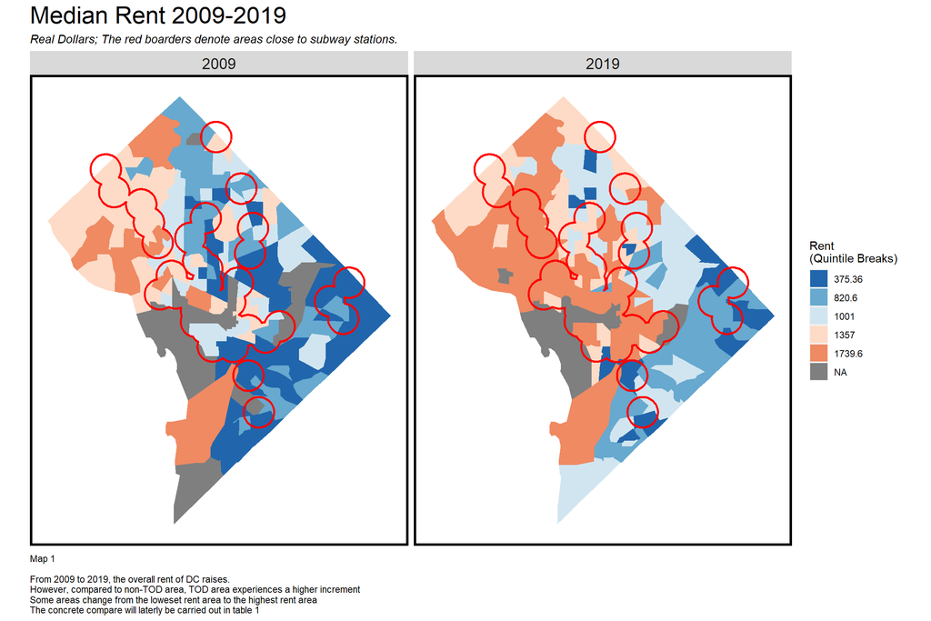

```r
ggplot(crowdata_todornot)+
  geom_sf(color=NA,aes(fill = q5(MedRent.inf))) +
  geom_sf(data = justbuffer, fill = "transparent", color = "red",size=1)+
  scale_fill_manual(values = palette5,
                    labels = qBr(crowdata_todornot, "MedRent.inf"),
                    name = "Rent\n(Quintile Breaks)") +
  labs(
      title = "Median Rent 2009-2019",
      subtitle = "Real Dollars; The red boarders denote areas close to subway stations.",
      caption =
"Map 1

From 2009 to 2019, the overall rent of DC raises.
However, compared to non-TOD area, TOD area experiences a higher increment
Some areas change from the loweset rent area to the highest rent area
The concrete compare will laterly be carried out in table 1"
      ) +
  facet_wrap(~year)+
  mapTheme() +
  theme(plot.title = element_text(size=22))
```

#### Median Household Income

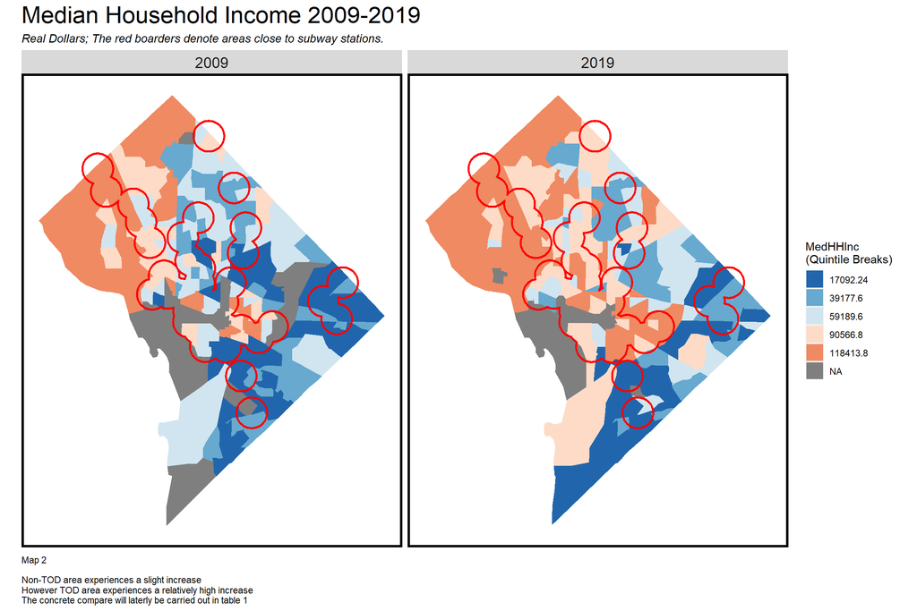

```r
ggplot(crowdata_todornot)+
  geom_sf(color=NA,aes(fill = q5(MedHHInc.inf))) +
  geom_sf(data = justbuffer, fill = "transparent", color = "red",size=1)+
  scale_fill_manual(values = palette5,
                    labels = qBr(crowdata_todornot, "MedHHInc.inf"),
                    name = "MedHHInc\n(Quintile Breaks)") +
  labs(
    title = "Median Household Income 2009-2019",
    subtitle = "Real Dollars; The red boarders denote areas close to subway stations.",
    caption =
"Map 2

Non-TOD area experiences a slight increase
However TOD area experiences a relatively high increase
The concrete compare will laterly be carried out in table 1"
    ) +
  facet_wrap(~year)+
  mapTheme() +
  theme(plot.title = element_text(size=22))
```

[output not shown]

#### Total Population

##### From the maps, intuitive conclusions about population could not be drew. It seems like the total population has slightly increased.

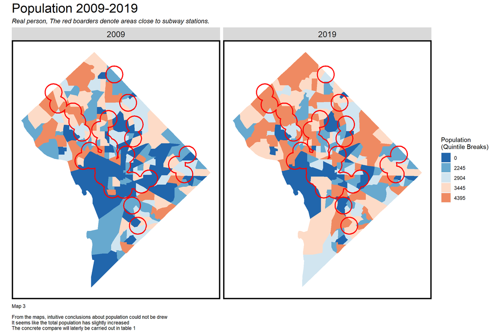

```r
ggplot(crowdata_todornot)+
  geom_sf(color=NA,aes(fill = q5(TotalPop))) +
  geom_sf(data = justbuffer, fill = "transparent", color = "red",size=1)+
  scale_fill_manual(values = palette5,
                    labels = qBr(crowdata_todornot, "TotalPop"),
                    name = "Population\n(Quintile Breaks)") +
  labs(
    title = "Population 2009-2019",
    subtitle = "Real person, The red boarders denote areas close to subway stations.",
    caption =
"Map 3

From the maps, intuitive conclusions about population could not be drew
It seems like the total population has slightly increased
The concrete compare will laterly be carried out in table 1"
    ) +
  facet_wrap(~year)+
  mapTheme() +
  theme(plot.title = element_text(size=22))
```

#### Population of Bachelor

##### Both in non-TOD & TOD area, bachelors take a greater proportion. The changes of population of bachelors in TOD and non-TOD area seem are at same pace.

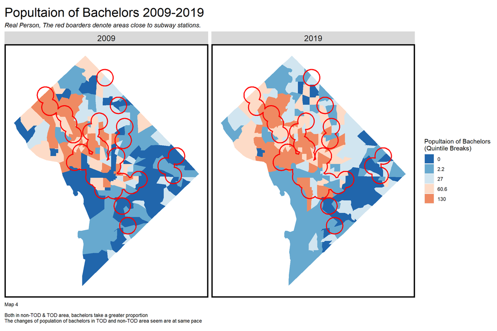

```r
pplBachelor <-
  crowdata_todornot%>%
  mutate(Bachelors=pctBachelors*TotalPop)

ggplot(crowdata_todornot)+
  geom_sf(data= pplBachelor,color=NA,aes(fill = q5(Bachelors))) +
  geom_sf(data = justbuffer, fill = "transparent", color = "red",size=1)+
  scale_fill_manual(values = palette5,
                    labels = qBr(pplBachelor, "Bachelors"),
                    name = "Popultaion of Bachelors\n(Quintile Breaks)") +
  labs(
    title = "Popultaion of Bachelors 2009-2019",
    subtitle = "Real Person, The red boarders denote areas close to subway stations.",
    caption =
      "Map 4

Both in non-TOD & TOD area, bachelors take a greater proportion
The changes of population of bachelors in TOD and non-TOD area seem are at same pace"
    ) +
  facet_wrap(~year)+
  mapTheme() +
  theme(plot.title = element_text(size=22))
```

## Summary Table 1

##### From the table, we can see that the percentage of bachelor in two areas stay nearly the same. In the TOD area, the percentage of poverty has decreased by 6%, while the one from non-TOD area stay same. In the non-TOD area, the percentage of white people has decreased by 22%. Since the total population becomes larger, we can not say the poverty has decreased and the white have move out from the non-TOD area. However, rents in TOD area experienced a larger increase than the non-TOD area.

```r
alldata.Summary %>%
  unite(year.TOD, year, TOD, sep = ": ", remove = T) %>%
  gather(Variable, Value, -year.TOD) %>%
  mutate(Value = round(Value, 2)) %>%
  spread(year.TOD, Value) %>%
  kable() %>%
   kable_styling(c("striped", "hover", "condensed", "responsive"),full_width = T) %>%
   column_spec(1:1,bold=T,background="#e0e0e0")%>%
   row_spec(0:0,background="#e0e0e0")%>%
   footnote(general_title = "Summary of DC indicators between 2009 & 2019",
            general =
"Table 1

From the table, we can see that the percentage of bachelor in two areas stay nearly the same
In the TOD area, the percentage of poverty has decreased by 6%, while the one from non-TOD area stay same
In the non-TOD area, the percentage of white people has decreased by 22%
Since the total population becomes larger,
we can not say the poverty has decreased and the white have move out from the non-TOD area
However, rents in TOD area experienced a larger increase than the non-TOD area."
            )
```

| Variable | 2009: Non-TOD | 2009: TOD | 2019: Non-TOD | 2019: TOD |
| --- | --- | --- | --- | --- |
| Percent_Bach | 0.02 | 0.04 | 0.02 | 0.03 |
| Percent_Poverty | 0.18 | 0.23 | 0.18 | 0.17 |
| Percent_White | 0.56 | 0.59 | 0.34 | 0.61 |
| Population | 2996.05 | 2869.95 | 3572.93 | 3767.50 |
| Rent | 910.39 | 968.29 | 1358.34 | 1642.61 |

Summary of DC indicators between 2009 & 2019  
Table 1 From the table, we can see that the percentage of bachelor in two areas stay nearly the same In the TOD area, the percentage of poverty has decreased by 6%, while the one from non-TOD area stay same In the non-TOD area, the percentage of white people has decreased by 22% Since the total population becomes larger, we can not say the poverty has decreased and the white have move out from the non-TOD area However, rents in TOD area experienced a larger increase than the non-TOD area.

## Grouped Bar Plot 1

##### The grouped bar plot further convinces the conclusions from the table, more intuitive and statistic.

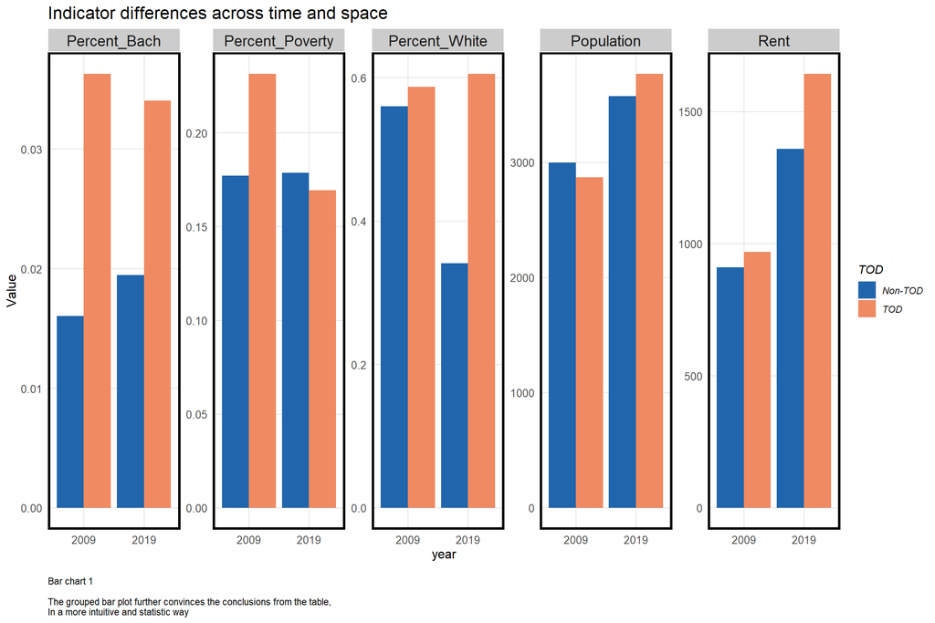

```r
alldata.Summary %>%
  gather(Variable, Value, -year, -TOD) %>%
  ggplot(aes(year, Value, fill = TOD)) +
  geom_bar(stat = "identity", position = "dodge") +
  facet_wrap(~Variable, scales = "free", ncol=5) +
  scale_fill_manual(values = c("#2166ac", "#ef8a62")) +
  labs(
    title = "Indicator differences across time and space",
    caption="
Bar chart 1

The grouped bar plot further convinces the conclusions from the table,
In a more intuitive and statistic way"
    ) +
  plotTheme() + theme(legend.position="right")
```

## Graduated symbol maps of population and rent

```r
selectCentroids <-
  st_centroid(crowdata)[justbuffer,] %>%
  st_sf()
```

##### The population distribution has remained the same. Except in the south area of downtown, the geological locations of population has changed a little.

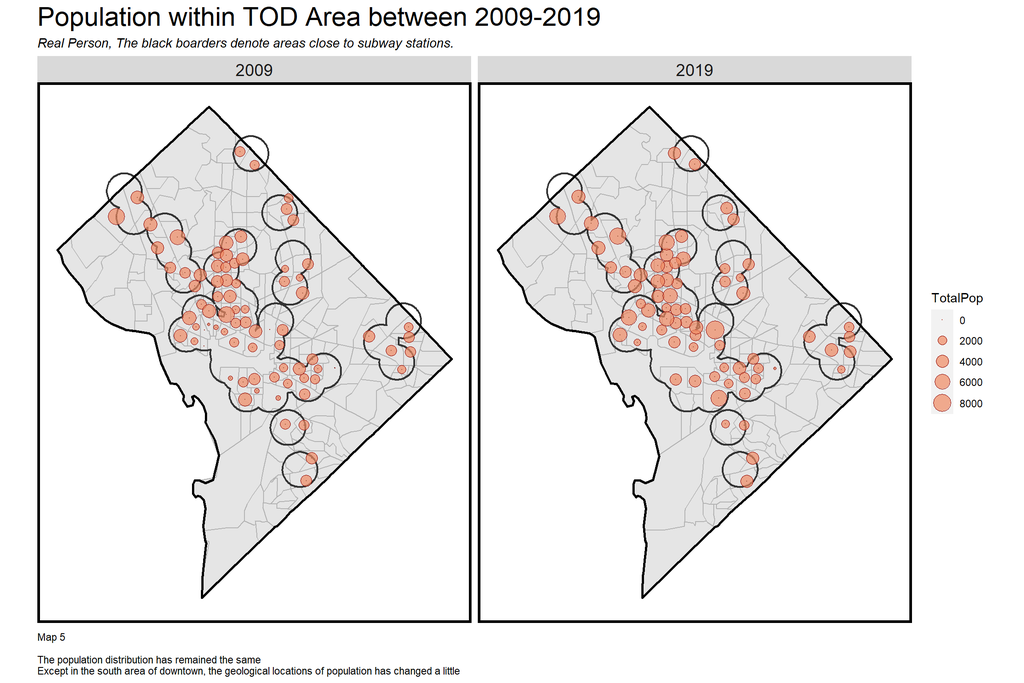

```r
ggplot() +
  geom_sf(data=crowdata,color="gray70")+
  geom_sf(data=justbuffer,fill = "transparent",color="gray20",size=0.75)+
  geom_sf(data=unionbdry,fill = "transparent",color="black",size=1)+
  geom_sf(data = selectCentroids,size=0.1)+
  geom_sf(data = selectCentroids,
          pch=21,
          aes(size = TotalPop),
          fill = alpha("#ef8a62", 0.7),
          color="darkred")+
  facet_wrap(~year)+
  scale_size(range = c(0,7))+
  scale_fill_manual(labels = qBr(selectCentroids, "TotalPop"),
          name = "Popultaion\n(Quintile Breaks)") +
  labs(
    title = "Population within TOD Area between 2009-2019",
    subtitle = "Real Person, The black boarders denote areas close to subway stations.",
    caption=
"Map 5

The population distribution has remained the same
Except in the south area of downtown, the geological locations of population has changed a little"
    ) +
  mapTheme()+
  theme(plot.title = element_text(size=22))
```

##### The rent in TOD area has experienced a big increase. Most of the increases are mainly positioned at the intersection area of TOD area and downtown. This makes us difficult to rule out the possible cause of rich resources in downtown area.

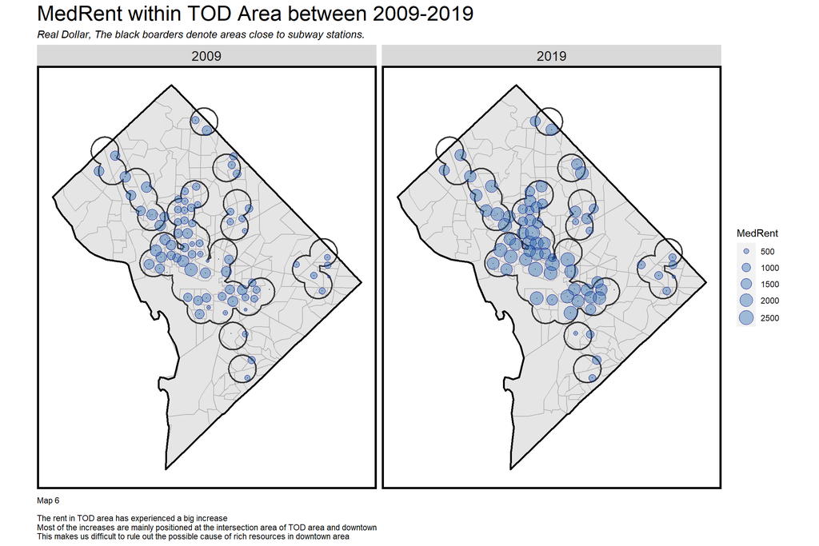

```r
ggplot() +
  geom_sf(data=crowdata,color="gray70")+
  geom_sf(data=justbuffer,fill = "transparent",color="gray20",size=0.75)+
  geom_sf(data=unionbdry,fill = "transparent",color="black",size=1)+
  geom_sf(data = selectCentroids,size=0.1)+
  geom_sf(data = selectCentroids,
          pch=21,
          aes(size = MedRent),
          fill = alpha("#2166ac", 0.4),
          color="darkblue")+
  facet_wrap(~year)+
  scale_size(range = c(0,7))+
  scale_fill_manual(labels = qBr(selectCentroids, "MedRent"),
                    name = "MedRent\n(Quintile Breaks)") +
  labs(
    title = "MedRent within TOD Area between 2009-2019",
    subtitle = "Real Dollar, The black boarders denote areas close to subway stations.",
    caption=
"Map 6

The rent in TOD area has experienced a big increase
Most of the increases are mainly positioned at the intersection area of TOD area and downtown
This makes us difficult to rule out the possible cause of rich resources in downtown area"
    ) +
  mapTheme()+theme(plot.title = element_text(size=22))
```

## Rent as a function of Distance to Statio

##### Data Wrangling

```r
justbuffer.union=st_union(justbuffer)%>%
  st_sf()

WMATA.MRBuffer <-
  st_join(
    st_centroid(dplyr::select(crowdata, GEOID, year)),
    multipleRingBuffer(justbuffer.union,16093.44,804.672)) %>%
  st_drop_geometry() %>%
  left_join(dplyr::select(crowdata, GEOID, MedRent, year),
            by=c("GEOID"="GEOID", "year"="year")) %>%
  st_sf() %>%
  replace_na(list(distance = 0))%>%
  mutate(distance = distance+804.672)
```

##### Distance to TOD area 2009-2019

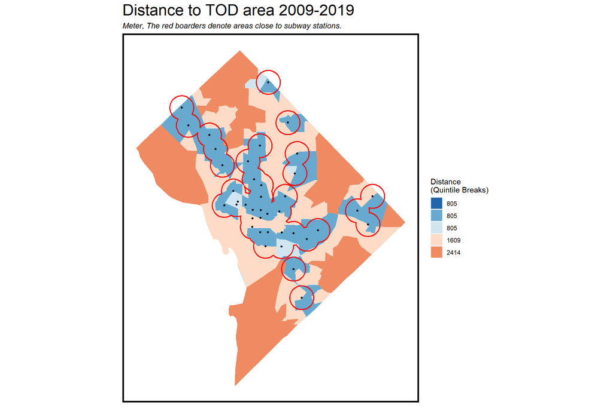

```r
ggplot(WMATA.MRBuffer)+
  geom_sf(color=NA,aes(fill = q5(distance))) +
  geom_sf(data = WMATAStops,size=1)+
  geom_sf(data=crowdata,fill = "transparent",color=NA)+
  geom_sf(data = justbuffer, fill = "transparent", color = "red",size=0.75)+
  scale_fill_manual(values = palette5,
                    labels = qBr(WMATA.MRBuffer, "distance"),
                    name = "Distance\n(Quintile Breaks)") +
  labs(
    title = "Distance to TOD area 2009-2019",
    subtitle = "Meter, The red boarders denote areas close to subway stations.",
    ) +
  mapTheme() +
  theme(plot.title = element_text(size=22))
```

##### Multiple Buffer Rings

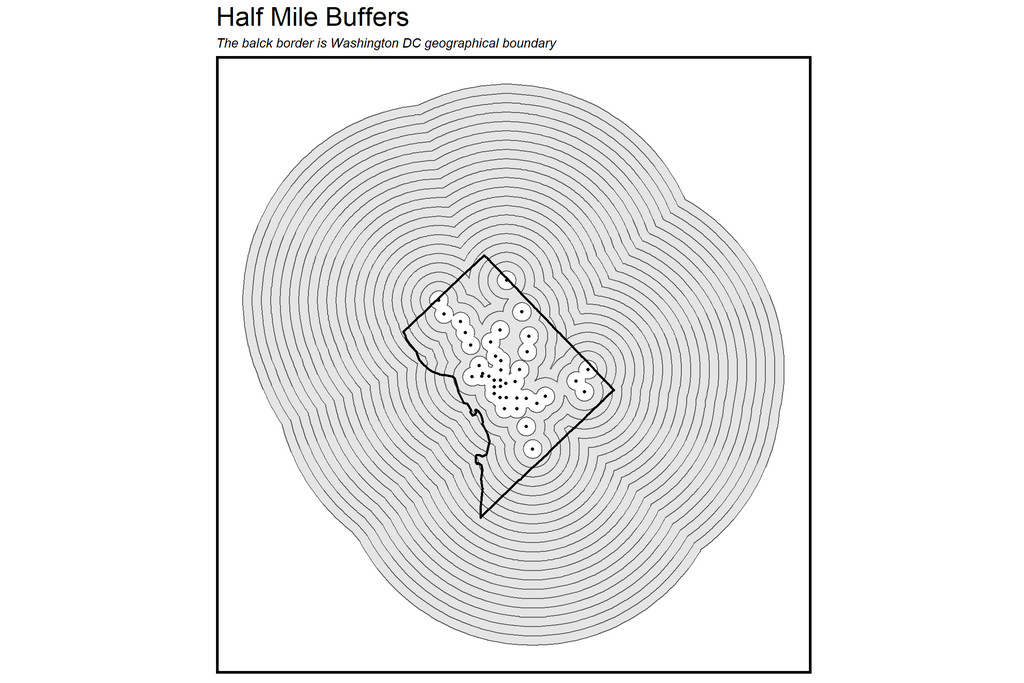

```r
ggplot() +
  geom_sf(data=multipleRingBuffer(justbuffer.union,16093.44,804.672))+
  geom_sf(data=unionbdry,fill = "transparent",color="black",size=1)+
  geom_sf(data = WMATAStops,size=1)+
  labs(
    title = "Half Mile Buffers",
    subtitle="The balck border is Washington DC geographical boundary"
    ) +
  mapTheme()+  theme(plot.title = element_text(size=22))
```

```r
cavgRent=WMATA.MRBuffer%>%
  group_by(year,distance)%>%
  summarise(avgRent=mean(MedRent,na.rm=TRUE))
```

## Rent as a function of Distance to Station

##### From this line chart, we can tell that as distance grow, the rents in TOD or non-TOD area will decrease. However, when distance is above 2500 meters, the rents in TOD or non-TOD area will increase as distance increases. After that, the rent continues decreasing with distance increasing. This may be explained by people’s favor toward center city’s rich resources and suburban area’s good community

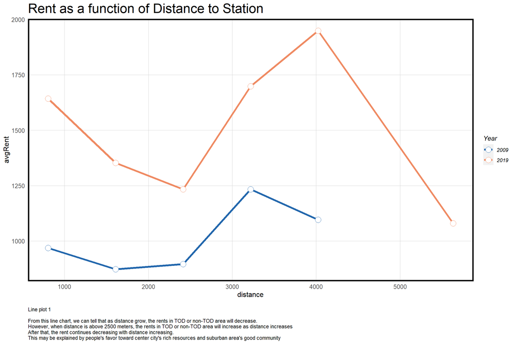

```r
ggplot(cavgRent, aes(y=avgRent, x=distance)) +
  geom_line(aes(group=year, color=year), size = 1.5) +
  geom_point(aes(color=year), size = 4.5,shape = 21, fill = "white") +
  scale_color_manual(values = c("#2166ac", "#ef8a62"),name="Year")+
  labs(
    title = "Rent as a function of Distance to Station",
    caption = "
Line plot 1

From this line chart, we can tell that as distance grow, the rents in TOD or non-TOD area will decrease.
However, when distance is above 2500 meters, the rents in TOD or non-TOD area will increase as distance increases
After that, the rent continues decreasing with distance increasing.
This may be explained by people's favor toward center city's rich resources and suburban area's good community"
    ) +
  plotTheme() + theme(plot.title = element_text(size=22),legend.position="right")
```

## Relationship between crime, transit access and rents

##### Read and wrangle crime data

```r
DCrime19 <-
  (st_read("https://opendata.arcgis.com/datasets/f08294e5286141c293e9202fcd3e8b57_1.geojson")%>%
     select(CCN, OFFENSE)%>%
     dplyr::filter(OFFENSE=='ROBBERY')%>%
     mutate(year=2019,counter=1)%>%
  st_transform(st_crs(rawdata19)))

DCrime09 <-
  (st_read("https://opendata.arcgis.com/datasets/73cd2f2858714cd1a7e2859f8e6e4de4_33.geojson")%>%
     select(CCN, OFFENSE)%>%
     dplyr::filter(OFFENSE=='ROBBERY')%>%
     mutate(year=2009,counter=1)%>%
  st_transform(st_crs(rawdata19)))

cDCrime <- rbind(DCrime09,DCrime19)
cDCrime <-
  rbind(
      cDCrime[justbuffer,] %>%
        st_drop_geometry() %>%
        left_join(cDCrime) %>%
        st_sf() %>%
        mutate(TOD = "TOD"),
      cDCrime[justbuffer, op = st_disjoint] %>%
        st_drop_geometry() %>%
        left_join(cDCrime) %>%
        st_sf() %>%
        mutate(TOD = "Non-TOD"))

cDCrime.MRBuffer <-
  st_join(
    dplyr::select(cDCrime, CCN, year),
    multipleRingBuffer(justbuffer.union,16093.44,804.672)) %>%
  st_drop_geometry() %>%
  left_join(dplyr::select(cDCrime, CCN, year,counter,TOD),
            by=c("CCN"="CCN", "year"="year")) %>%
  st_sf() %>%
  replace_na(list(distance = 0))%>%
  mutate(distance = distance+804.672)

crimesum <-
  cDCrime.MRBuffer%>%
  st_drop_geometry() %>%
  group_by(year,distance)%>%
  summarise(total=sum(counter))
```

#### Incidences of Rubbery as a function of Distance to Station

##### This line chart tells that as distance increase. The total number of rubbery incidence decreases. This may be the case that as distance increase, the population density decreases

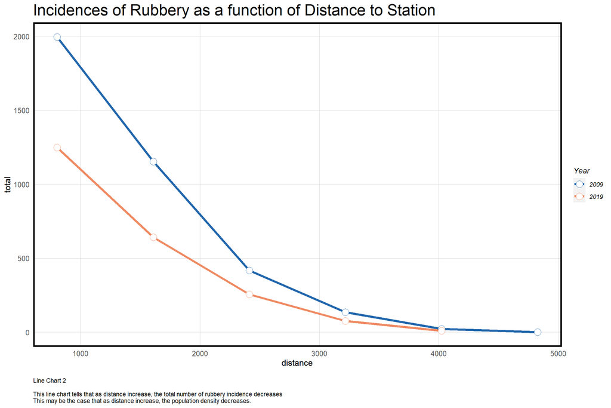

```r
ggplot()+
  geom_line(data=crimesum,aes(y=total, x=distance,group = year, color=as.character(year)), size = 1.5) +
  geom_point(data=crimesum,aes(y=total, x=distance,group = year,color=as.character(year)), size = 4.5,shape = 21, fill = "white") +
  scale_color_manual(values = c("#2166ac", "#ef8a62"),name="Year")+
  labs(
    title = "Incidences of Rubbery as a function of Distance to Station",
    caption = "
Line Chart 2

This line chart tells that as distance increase, the total number of rubbery incidence decreases
This may be the case that as distance increase, the population density decreases."
    ) +
  plotTheme() + theme(plot.title = element_text(size=22),legend.position="right")
```

#### Rent as a function of Distance to Station

##### From this line chart, we can tell that as distance grow, the rents in TOD or non-TOD area will decrease. However, when distance is above 2500 meters, the rents in TOD or non-TOD area will increase as distance increases. After that, the rent continues decreasing with distance increasing.This may be explained by people’s favor toward center city’s rich resources and suburban area’s good community"

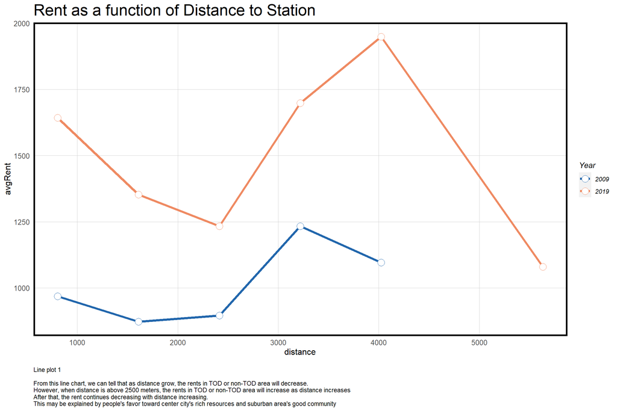

```r
ggplot(cavgRent, aes(y=avgRent, x=distance)) +
  geom_line(aes(group=year, color=year), size = 1.5) +
  geom_point(aes(color=year), size = 4.5,shape = 21, fill = "white") +
  scale_color_manual(values = c("#2166ac", "#ef8a62"),name="Year")+
  labs(
    title = "Rent as a function of Distance to Station",
    caption = "
Line plot 1

From this line chart, we can tell that as distance grow, the rents in TOD or non-TOD area will decrease.
However, when distance is above 2500 meters, the rents in TOD or non-TOD area will increase as distance increases
After that, the rent continues decreasing with distance increasing.
This may be explained by people's favor toward center city's rich resources and suburban area's good community"
  ) +
  plotTheme() + theme(plot.title = element_text(size=22),legend.position="right")
```

#### Instances of Ruberies and Median Rent

##### The total number of rubbery instance decreases from 2009 to 2019. Outside the TOD area, the instance density decreases and mainly concentrates at the south of Washington DC.

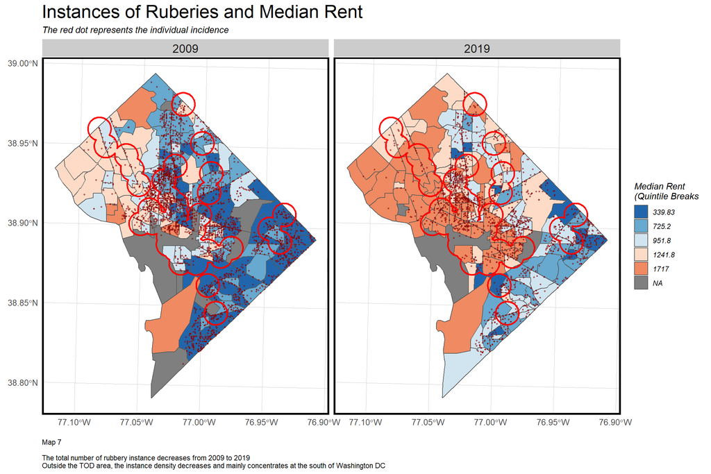

```r
ggplot()+
  geom_sf(data = crowdata, aes(fill = q5(MedRent)))+
  geom_sf(data = cDCrime,
          color = "darkred",size=0.5,alpha=0.5) +
  geom_sf(data = justbuffer, fill = "transparent", color = "red", size = 1) +
  scale_fill_manual(values = palette5,
                    labels = qBr(crowdata, "MedRent"),
                    name = "Median Rent \n(Quintile Breaks") +
  facet_wrap(~year)+
  labs(
    title = "Instances of Ruberies and Median Rent",
    subtitle="The red dot represents the individual incidence",
    caption = "
Map 7

The total number of rubbery instance decreases from 2009 to 2019
Outside the TOD area, the instance density decreases and mainly concentrates at the south of Washington DC"
    ) +
  plotTheme() + theme(plot.title = element_text(size=22),legend.position="right")
```

#### Crime data summary

##### The total number of rubbery instance decreases from 2009 to 2019. Outside the TOD area, the number of rubbery instance decreases

```r
cDCrime.Summary <-
  st_drop_geometry(cDCrime) %>%
  group_by(year, TOD) %>%
  summarize(Criminalsum = sum(counter, na.rm = T)) %>%
  unite(year.TOD, year, TOD, sep = ": ", remove = T)
cDCrime.Summary %>%
  gather(Variable,Value,-year.TOD) %>%
  spread(year.TOD, Value) %>%
  kable() %>%
  kable_styling(c("striped", "hover", "condensed", "responsive"),full_width = T) %>%
  column_spec(1:1,bold=T,background="#e0e0e0")%>%
  row_spec(0:0,background="#e0e0e0")%>%
  footnote(general_title = "Summary of rubbery incidences of Washington DC between 2009 & 2019",
           general ="Table 2

The total number of rubbery instance decreases from 2009 to 2019
Outside the TOD area, the number of rubbery instance decreases.")
```

| Variable | 2009: Non-TOD | 2009: TOD | 2019: Non-TOD | 2019: TOD |
| --- | --- | --- | --- | --- |
| Criminalsum | 1730 | 1995 | 983 | 1248 |

Summary of rubbery incidences of Washington DC between 2009 & 2019  
Table 2 The total number of rubbery instance decreases from 2009 to 2019 Outside the TOD area, the number of rubbery instance decreases.

#### Crime data bar plot

##### The total number of rubbery instance decreases from 2009 to 2019. Outside the TOD area, the instance density decreases and mainly concentrates at the south of Washington DC.

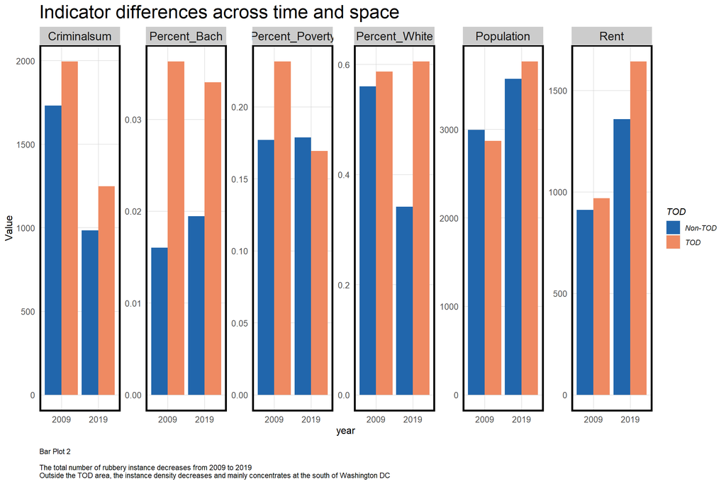

```r
cDCrime.Summary2 <-
  st_drop_geometry(cDCrime) %>%
  group_by(year, TOD) %>%
  summarize(Criminalsum = sum(counter, na.rm = T))

class(cDCrime.Summary2$year) = "character"

cDCrime.Summary3 <-
  cDCrime.Summary2 %>%
  left_join(.,alldata.Summary,
            by=c("TOD"="TOD", "year"="year"))%>%
  gather(Variable, Value, -year, -TOD)

ggplot(cDCrime.Summary3,
       aes(year, Value, fill = TOD)) +
  geom_bar(stat = "identity", position = "dodge") +
     facet_wrap(~Variable, scales = "free", ncol=6) +
     scale_fill_manual(values = c("#2166ac", "#ef8a62")) +
     labs(
       title = "Indicator differences across time and space",
       caption="
Bar Plot 2

The total number of rubbery instance decreases from 2009 to 2019
Outside the TOD area, the instance density decreases and mainly concentrates at the south of Washington DC "
       ) +
  plotTheme() + theme(plot.title = element_text(size=22),legend.position="right")
```